# 기호 수학(Symbolic Math)

수학 통계: 중등

이광춘

[Tidyverse Korea](https://www.facebook.com/groups/tidyverse/)

2021-01-30

# 1 중학교 1학년

이지통계 프로그램 http://www.ebsmath.co.kr/easyTong을 참고하여 줄기잎그림과 비교해보자.

## 1.1 자료의 정리와 해석

`scale = 2`로 지정하여 나이 십자리가 기준 줄기(stem)가 되고 나이 일자리가 잎(leaf)가 되도록 그래프를 그린다. 이를 통해서 가장 최고령자는 78세임을 알 수 있고 40세 미만은 17, 32, 39 3명임을 알 수 있다.

**변량(Variable)**은 변한다는 뜻을 갖는 것으로 노벨평화상 수상자의 나이가 고정되지 않고 변화하는 특징을 갖는 것을 확인할 수 있다.

```r
library(tidyverse)
library(aplpack)

novel_age <- c(63, 78, 56, 64, 63, 66, 59, 71, 48, 45, 73, 39, 32, 60, 17)

stem(novel_age, scale = 2)
```

```
  The decimal point is 1 digit(s) to the right of the |

  1 | 7
  2 |
  3 | 29
  4 | 58
  5 | 69
  6 | 03346
  7 | 138
```

```r
# stem.leaf(novel_age, unit = 2, m = 1, depths = FALSE)
```

어느 중학교의 여학생과 남학생 각각 10명이 하루동안 휴대전화로 발송한 문자의 횟수를 조사하여 양쪽으로 비교를 할 수 있도록 줄기잎 그래프를 그려보자.[^1]

```r
female_sms <- c(31, 38, 67, 45, 59, 79, 36, 83, 72, 74)
male_sms   <- c(17, 18, 25, 78, 62, 67, 22, 57, 23, 39)

stem.leaf.backback(female_sms, male_sms, unit = 1, back.to.back = TRUE, add.more.blanks = 5, show.no.depths = FALSE)
```

```
___________________________________
  1 | 2: represents 12, leaf unit: 1
     female_sms     male_sms
___________________________________
               | 1 |78         2
               | 2 |235       (3)
   3        861| 3 |9         (1)
   4          5| 4 |
  (1)         9| 5 |7          4
  (1)         7| 6 |27         3
   4        942| 7 |8          1
   1          3| 8 |
               | 9 |
___________________________________
n:           10     10
___________________________________
```

## 1.2 도수분포표

도수분포표는 영어로 Frequency Table로 빈도표로 간략화 시킬 수 있고 추구하는 바는 특정 구간에 출현횟수가 몇개가 되는지를 표로 나타낸 것이다.

합창단 나이를 벡터로 표현한다. 벡터를 데이터프레임으로 바꾸고 난 후 나머지 연산을 통해 몫만 취해 연령대를 구한다. 그리고 나서 각 연령대가 범주형 변수이기 때문에 빈도를 `count()` 함수로 구해서 개수하면 된다. 가장 빈도가 많은 연령대는 “40대”로 파악된다.

```r
glee_club_age <- c(30, 41, 43, 45, 38, 51, 56, 42, 36, 39, 33, 49, 27, 52, 48, 29, 25, 26, 40, 51)

glee_club_tbl <- tibble(age = glee_club_age)

glee_club_tbl %>%
  mutate(연령대 = age %/% 10) %>%
  mutate(연령대 = glue::glue("{연령대}0대")) %>%
  count(연령대, name = "도수(명)") %>%
  add_row(연령대="합계", `도수(명)`=20)
```

```
# A tibble: 5 x 2
  연령대 `도수(명)`
  <glue>      <dbl>
1 20대            4
2 30대            5
3 40대            7
4 50대            4
5 합계           20
```

## 1.3 도수분포 시각화

상기와 같은 도수분포를 막대그래프를 사용해서 시각화하면 좀더 명확한 의미를 알 수 있다.

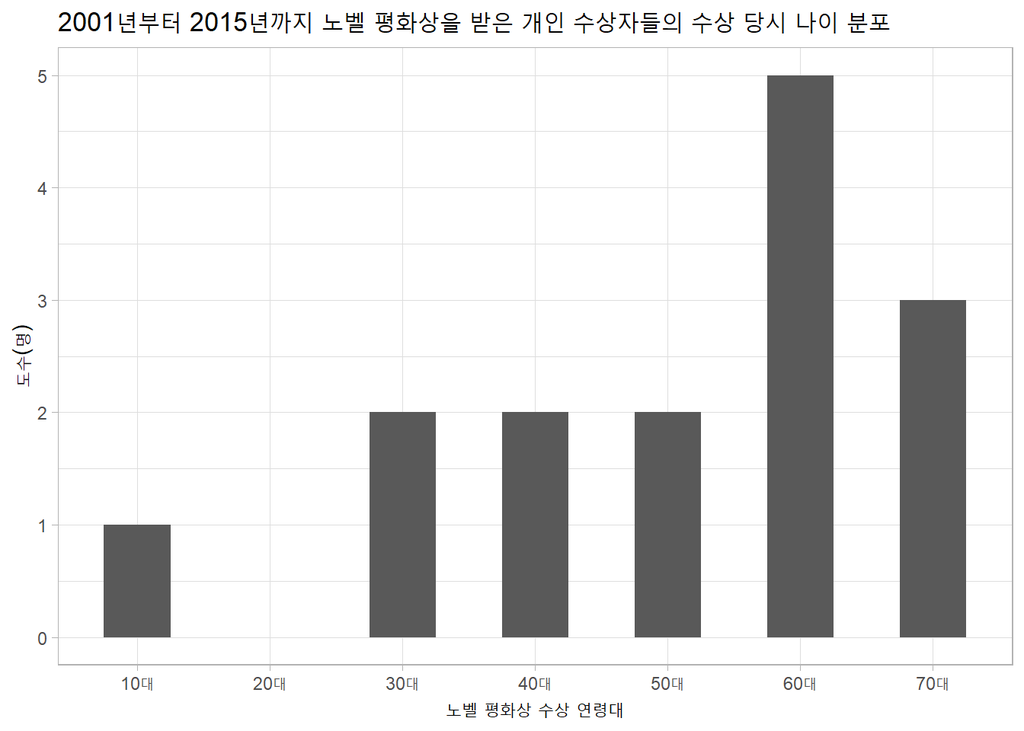

```r
novel_dat <- tibble(나이 = novel_age)

novel_tbl <- novel_dat %>%
  mutate(연령대 = 나이 %/% 10) %>%
  mutate(연령대 = glue::glue("{연령대}0대")) %>%
  count(연령대, name = "도수(명)") %>%
  add_row(연령대 = "20대", `도수(명)` = 0) %>%
  arrange(연령대)

novel_tbl %>%
  ggplot(aes(x= 연령대, y = `도수(명)`)) +
    geom_col(width = 0.5, stat = "identity") +
    theme_light() +
    labs(x     = "노벨 평화상 수상 연령대",
         title =  "2001년부터 2015년까지 노벨 평화상을 받은 개인 수상자들의 수상 당시 나이 분포")
```

동일한 그래프를 원그래프를 사용해서 표현해보자.

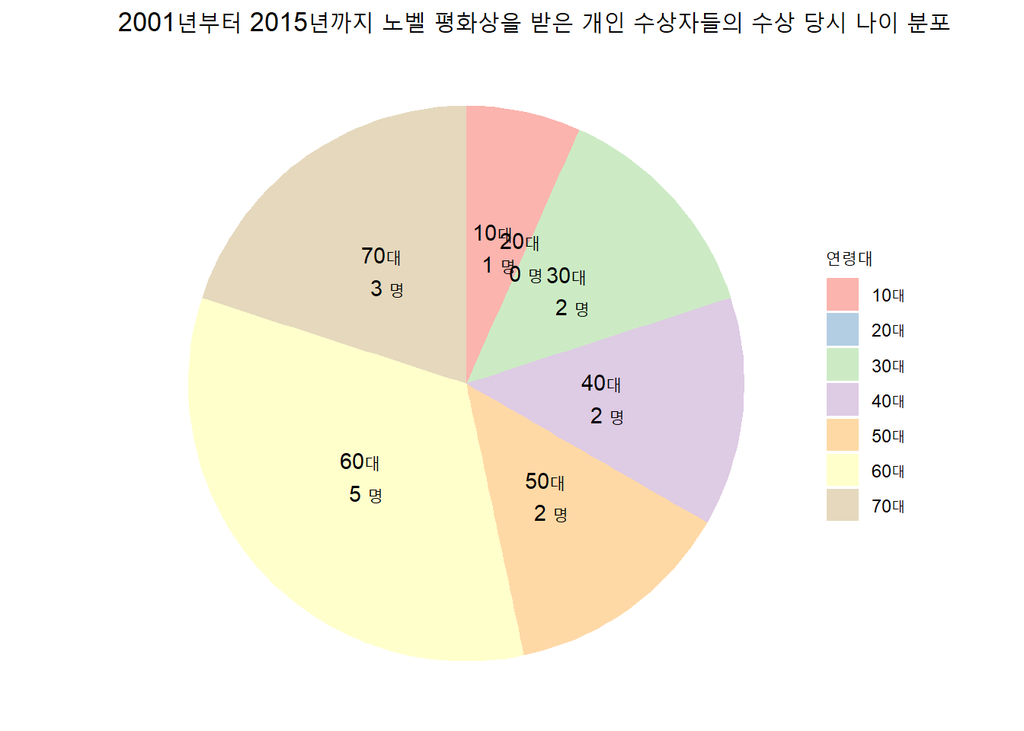

```r
novel_tbl %>%
  ggplot(aes(x= "", y = `도수(명)`, fill = 연령대)) +
    geom_col() +
    coord_polar(theta = "y", start = 0, direction = -1) +
    geom_text(aes(label = paste(연령대, "\n", `도수(명)`, "명")),
            position = position_stack(vjust = 0.5)) +
    theme_void() +
    scale_fill_brewer(palette = "Pastel1") +
    labs(x     = "노벨 평화상 수상 연령대",
         title =  "2001년부터 2015년까지 노벨 평화상을 받은 개인 수상자들의 수상 당시 나이 분포")
```

## 1.4 도수분포다각형 시각화

도수분포다각형은 Frequency Polygon을 번역한 것으로 앞으로 다룰 히스토그램과 밀접한 연관관계가 있다. 노벨평화상 수상자를 연령대별로 `seq(10, 80, by=10)`을 사용해서 10, 20, 30, 40, 50, 60, 70, 80 구간을 만들어 이를 `geom_freqpoly()`를 사용하여 시각화한다.

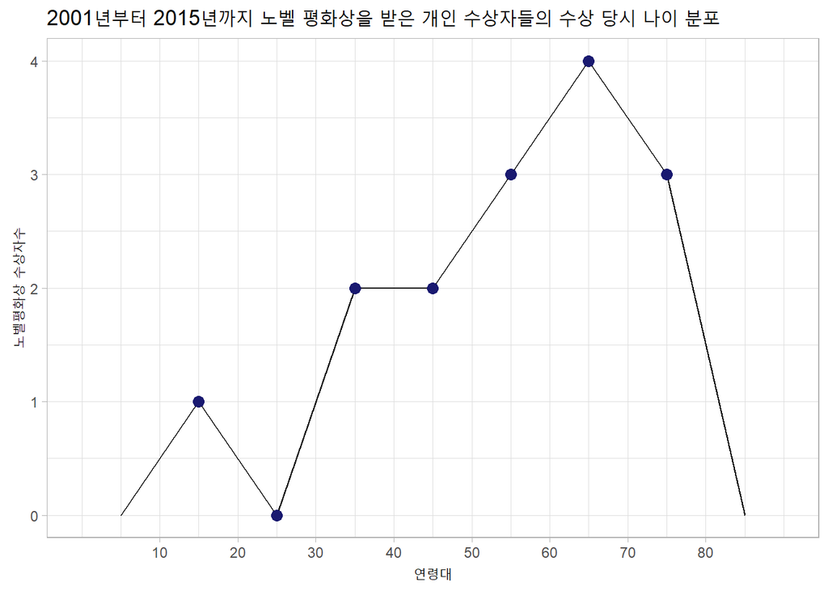

```r
novel_dat %>%
  ggplot(aes(x= `나이`)) +
    geom_freqpoly(breaks= seq(10, 80, by=10)) +
    geom_point(stat="bin", aes(y=..count..), breaks= seq(10, 80, by=10), size = 3, color ="midnightblue") +
    scale_x_continuous(breaks = seq(10, 80, by=10)) +
    labs(x = "연령대",
         y = "노벨평화상 수상자수",
         title =  "2001년부터 2015년까지 노벨 평화상을 받은 개인 수상자들의 수상 당시 나이 분포") +
    theme_light()
```

## 1.5 상대도수

상대도수는 Relative Frequency를 번역한 것으로 앞서 빈도수를 절대도수 Absolute Frequency를 나타낸 것인데 두집단이상을 비교할 때 전체를 100으로 두고 퍼센트를 사용해서 비율을 구하듯이 전체 도수 총계를 분모에 두고 각 해당 사건이 발생된 빈도를 나눠 상대 도수를 구한다. 이렇게 상대 도수를 구하게 되면 두 집단을 비교할 때 유용하다. 먼저 남녀학생이 보낸 SMS 문자건수를 범주화하여 각각 빈도수를 계산한다.

```r
sms_dat <- tibble(여자 = female_sms,
                  남자 = male_sms)

sms_tbl <- sms_dat %>%
  pivot_longer(cols = everything(), names_to = "성별", values_to = "문자발송건수") %>%
  mutate(SMS발송범주 = cut_width(`문자발송건수`, width=10, boundary = 0, closed = "left")) %>%
  count(성별, SMS발송범주, name = "명수") %>%
  pivot_wider(names_from = 성별, values_from = 명수, values_fill  = 0)

sms_tbl
```

```
# A tibble: 8 x 3
  SMS발송범주  남자  여자
  <fct>       <int> <int>
1 [10,20)         2     0
2 [20,30)         3     0
3 [30,40)         1     3
4 [50,60)         1     1
5 [60,70)         2     1
6 [70,80)         1     3
7 [40,50)         0     1
8 [80,90]         0     1
```

상대도수 공식에 의해 계급으로 표현된 `SMS발송범주`의 상대도수를 계산한다.

$$\text{어떤 계급의 상대도수} = \frac{\text{그 계급의 도수}}{\text{도수의 총합}}$$

```r
sms_tbl <- sms_tbl %>%
  mutate(남자_상대도수 = 남자 / sum(남자),
         여자_상대도수 = 여자 / sum(여자) )

sms_tbl
```

```
# A tibble: 8 x 5
  SMS발송범주  남자  여자 남자_상대도수 여자_상대도수
  <fct>       <int> <int>         <dbl>         <dbl>
1 [10,20)         2     0           0.2           0
2 [20,30)         3     0           0.3           0
3 [30,40)         1     3           0.1           0.3
4 [50,60)         1     1           0.1           0.1
5 [60,70)         2     1           0.2           0.1
6 [70,80)         1     3           0.1           0.3
7 [40,50)         0     1           0             0.1
8 [80,90]         0     1           0             0.1
```

이제 모든 데이터가 준비되었으니 절대도수로 그래프를 그려보고 상대도수로 그래프를 그려 비교해보자.

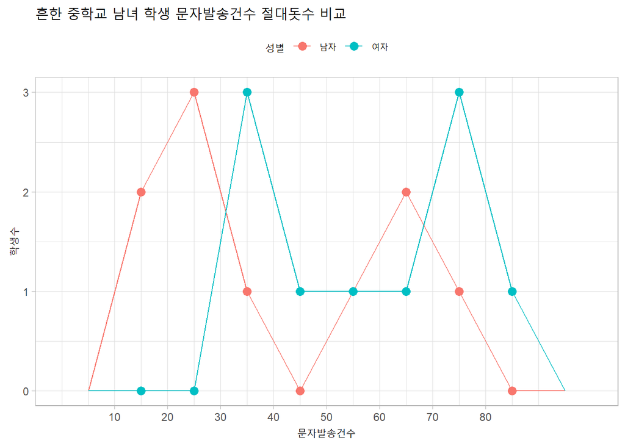

```r
sms_dat %>%
  pivot_longer(cols = everything(), names_to = "성별", values_to = "발송건수") %>%
  ggplot(aes(x= `발송건수`, group = 성별, color = 성별)) +
    geom_freqpoly(breaks= seq(10, 90, by=10)) +
    geom_point(stat="bin", aes(y=..count..), breaks= seq(10, 90, by=10), size = 3)  +
    scale_x_continuous(breaks = seq(10, 80, by=10)) +
    labs(x = "문자발송건수",
         y = "학생수",
         title =  "흔한 중학교 남녀 학생 문자발송건수 절대돗수 비교") +
    theme_light() +
    theme(legend.position = "top")
```

`geom_freqpoly`의 인자를 조정하여 절대도수가 아닌 상대도수를 표현하여 남녀를 상대적으로 비교할 수 있도록 `ggplot`으로 시각화한다.

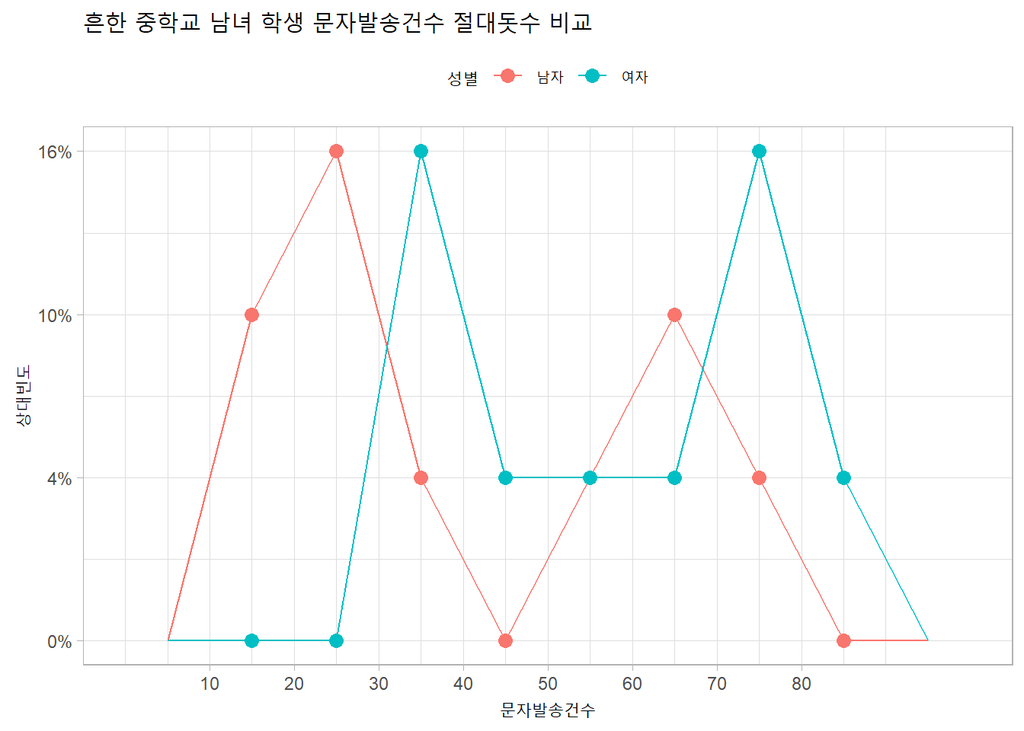

```r
sms_dat %>%
  pivot_longer(cols = everything(), names_to = "성별", values_to = "발송건수") %>%
  ggplot(aes(x= `발송건수`, group = 성별, color = 성별)) +
    geom_freqpoly(aes(y = stat(count) / sum(count)), breaks= seq(10, 90, by=10)) +
    geom_point(stat="bin", aes(y=..count.. / sum(..count..) ), breaks= seq(10, 90, by=10), size = 3)  +
    scale_x_continuous(breaks = seq(10, 80, by=10)) +
    scale_y_continuous(labels = scales::percent_format(accuracy = 2L)) +
    labs(x = "문자발송건수",
         y = "상대빈도",
         title =  "흔한 중학교 남녀 학생 문자발송건수 절대돗수 비교") +
    theme_light() +
    theme(legend.position = "top")
```

# 2 중1: 통계프로젝트

앞서 배운 도구를 바탕으로 통계프로젝트를 진행하여 통계표를 작성한다.

1. 주제정하기
2. 계획하기
3. 자료 수집하기
4. 자료 정리하기
5. 자료 해석하기
6. 발표자료 만들기
[^1]: [stackoverflow, “How do you make a comparative stem and leaf plot in R?”](https://stackoverflow.com/questions/25692421/how-do-you-make-a-comparative-stem-and-leaf-plot-in-r)

데이터 과학자 [이광춘](https://github.com/statkclee/) 저작

*kwangchun.lee.7@gmail.com*